# Weekly squad report

Weekly squad report Week ending Wednesday 31 March 2021 · Team A

21 Players trained

48,200 AU Squad load this week down 30% on last week

0.77 Average ACWR Safe range 0.8–1.5

1 Speak to first plus 11 to monitor

86% Wellness reporting 0 players sent none

**This week:** squad load was down 30% on last week. **1** player has both a load and a wellness flag and should be spoken to first; **11** more need monitoring.

## Players to review

Sorted by priority. “Speak to first” means load outside the safe range *and* wellness more than 0.5 SD below the player’s normal.

| Player | Team | Weekly load | vs last week | ACWR | Wellness (7d) | Status | Why flagged |
| --- | --- | --- | --- | --- | --- | --- | --- |
| A-6796 | Team A | 1,980 | −40% | 0.67 | −0.65 | Speak to first | ACWR below 0.8 · Low wellness |
| A-bcc0 | Team A | 2,400 | −34% | 0.77 | −0.37 | Monitor | ACWR below 0.8 |
| A-c4cc | Team A | 2,180 | −31% | 0.76 | 0.37 | Monitor | ACWR below 0.8 |
| A-5cd7 | Team A | 2,440 | −28% | 0.76 | −0.20 | Monitor | ACWR below 0.8 |
| A-560c | Team A | 2,300 | −34% | 0.74 | −0.08 | Monitor | ACWR below 0.8 |
| A-5a5b | Team A | 2,200 | −27% | 0.72 | −0.05 | Monitor | ACWR below 0.8 |
| A-3586 | Team A | 2,700 | −43% | 0.70 | 0.24 | Monitor | ACWR below 0.8 |
| A-ecdb | Team A | 2,070 | −38% | 0.68 | −0.18 | Monitor | ACWR below 0.8 |
| A-3e5f | Team A | 1,560 | −23% | 0.66 | −0.05 | Monitor | ACWR below 0.8 |
| A-f205 | Team A | 1,720 | −47% | 0.55 | −0.14 | Monitor | ACWR below 0.8 |
| A-82a0 | Team A | 1,420 | −56% | 0.52 | 0.75 | Monitor | ACWR below 0.8 |
| A-af71 | Team A | 1,250 | −60% | 0.49 | 0.02 | Monitor | ACWR below 0.8 |

## Load vs wellness

Each dot is a player. Shaded areas are outside the safe range.

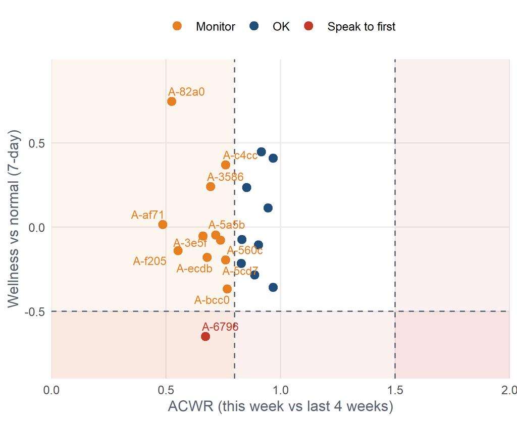

## Squad load, last 8 weeks

Total weekly load by team. This week is highlighted.

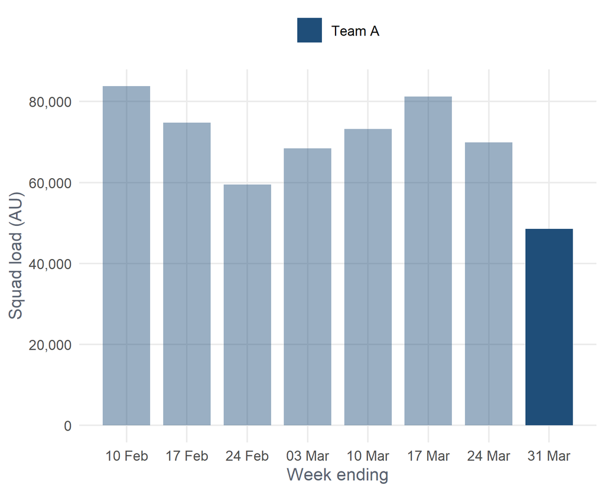

## Last four weeks for flagged players

Daily training load. The week under review is shaded.

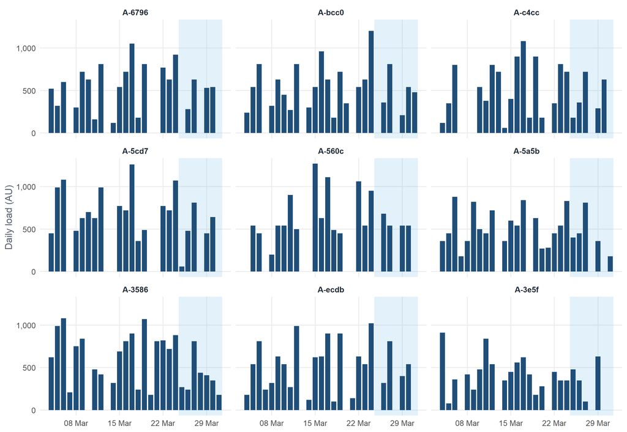

## Wellness reporting

86% of possible reports were completed this week. Players who sent none: **none, everyone reported**.

**NoteFull squad this week (click to expand)**

| Player | Team | Weekly load | ACWR | Monotony | Wellness (7d) | Reports | Status |
| --- | --- | --- | --- | --- | --- | --- | --- |
| A-affd | Team A | 2,690 | 0.97 | 1.96 | 0.41 | 5 | OK |
| A-2d44 | Team A | 2,780 | 0.97 | 1.10 | −0.36 | 7 | OK |
| A-78f2 | Team A | 3,210 | 0.95 | 1.99 | 0.11 | 7 | OK |
| A-d729 | Team A | 3,000 | 0.92 | 1.58 | 0.45 | 7 | OK |
| A-32fe | Team A | 2,020 | 0.90 | 1.06 | −0.11 | 6 | OK |
| A-4051 | Team A | 2,580 | 0.89 | 1.36 | −0.28 | 7 | OK |
| A-e920 | Team A | 2,690 | 0.85 | 1.57 | 0.24 | 6 | OK |
| A-b58a | Team A | 2,030 | 0.83 | 1.12 | −0.07 | 7 | OK |
| A-7059 | Team A | 2,980 | 0.83 | 1.81 | −0.22 | 5 | OK |
| A-bcc0 | Team A | 2,400 | 0.77 | 1.25 | −0.37 | 5 | Monitor |
| A-c4cc | Team A | 2,180 | 0.76 | 1.19 | 0.37 | 3 | Monitor |
| A-5cd7 | Team A | 2,440 | 0.76 | 1.06 | −0.20 | 7 | Monitor |
| A-560c | Team A | 2,300 | 0.74 | 1.14 | −0.08 | 7 | Monitor |
| A-5a5b | Team A | 2,200 | 0.72 | 1.19 | −0.05 | 6 | Monitor |
| A-3586 | Team A | 2,700 | 0.70 | 1.99 | 0.24 | 7 | Monitor |
| A-ecdb | Team A | 2,070 | 0.68 | 1.01 | −0.18 | 5 | Monitor |
| A-6796 | Team A | 1,980 | 0.67 | 1.07 | −0.65 | 7 | Speak to first |
| A-3e5f | Team A | 1,560 | 0.66 | 0.92 | −0.05 | 4 | Monitor |
| A-f205 | Team A | 1,720 | 0.55 | 0.71 | −0.14 | 7 | Monitor |
| A-82a0 | Team A | 1,420 | 0.52 | 0.78 | 0.75 | 7 | Monitor |
| A-af71 | Team A | 1,250 | 0.49 | 0.86 | 0.02 | 5 | Monitor |

**How flags work:** ACWR = acute (7-day) ÷ chronic (28-day) load, with the safe range taken as 0.8–1.5. Wellness (7d) = average of fatigue, soreness, sleep quality and stress z-scores over the week, where 0 is the player’s own normal. Monotony = mean ÷ SD of daily load over the week. Flags prompt a conversation; they are not a diagnosis.  
Data: SoccerMon (Midoglu et al., CC BY 4.0). Report generated 11 November 2026 with R and Quarto by Will Page.